# Making forest plots in R

# 1 Goal of tutorial

The main goal of this tutorial is to introduce functions from **forestploter** that can be used to make and edit forest plots. This is done by making the forest plot in Section 4, step by step. Additional variations of forest plots that could be of interest are shown in Section 5, Section 6, and Section 7.

The focus of all examples and exercises in this tutorial is to illustrate many of the elements of a forest plot made with **forestploter** that can be controlled, not to make plots that are necessarily *that* pretty (which is very subjective anyway). Feel free to explore the documentation/vignettes and diverge from the exercises along the way. In continuation of this, some aspects of the plots in this tutorial can be made in multiple ways. There might be better ways to achieve the desired results than the solutions shown in this tutorial.

# 2 Setup

## 2.1 Packages used in this tutorial

In this tutorial we use the following packages.

```r
# install.packages("forestploter")
# install.packages("ggplot2")
library(forestploter)
library(grid) # R base package,  no installation needed
```

Installing **ggplot2** is optional, we only use `ggplot2::ggsave()` briefly at one point. **forestploter** is built on grid graphics, and we need to use functions from **grid** to modify the forest plots we are going to make.

The only data wrangling done in this tutorial will be very basic, and done using base R functions. If you prefer to use e.g. **dplyr** or **data.table** functions instead, feel free to do so.

# 3 What is a forest plot

A forest plot is a graphical display of estimated results. Forest plots were originally developed to present results from a meta-analysis. There are many variations of forest plots, and they are useful in many contexts. A common use of forest plots is to report parameter estimates and confidence intervals (CI’s) from regression models, sometimes also including some descriptive statistics. A forest plot of this type could look like the plot below.

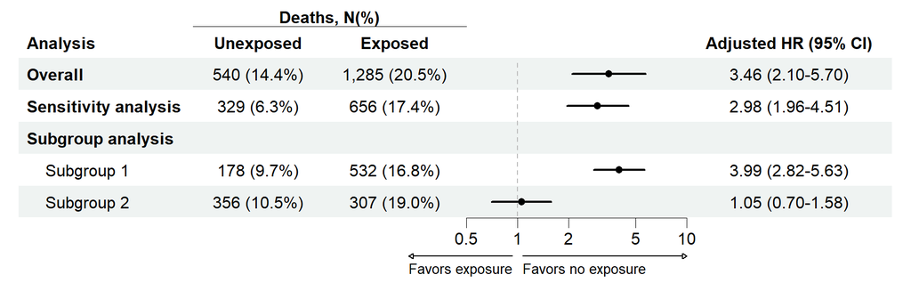

## 3.1 Packages to make forest plots

Many packages have been developed in R to facilitate making publication-ready forest plots. Below is a list of some packages of interest.

Curated list of R packages for making forest plots

| Package name | Notes |
| --- | --- |
| **meta** | General package for meta-analysis |
| **metafor** | General package for meta-analysis |
| **forester** | Not actively maintained? |
| **forestplot** |  |
| **forestploter** |  |
| **ggforestplot** | Not actively maintained? |

Since the main focus of this tutorial is not meta-analyses, we will not consider the **meta** and **metafor** package, whose main focus is to facilitate meta-analysis from start to end. Of the remaining packages, **forestploter** seems the most worthwhile to use in terms of being flexible, producing plots that look (subjectively) good, and being maintained actively. Therefore, we will focus on using that package in this tutorial. That being said, it could be worthwhile to explore some of the other packages if you need to make a forest plot, and you find that **forestploter** can’t produce the type of forest plot you want to make.

The main differences between **forestploter** and other packages that can make forest plots are:

- Focuses specifically on making forest plots.
- Forest plots are treated as tables, where elements are arranged in rows and columns. Users have full control over what and how to display the content in the plot.
- Graphical parameters are controlled using themes.
- Allows for ad hoc editing of plots.
- Support for drawing CI’s in multiple or grouped columns.

# 4 Forest plot - Regression estimates

In this section we will make a forest plot displaying estimates and confidence intervals from regression models, including some additional descriptive statistics.

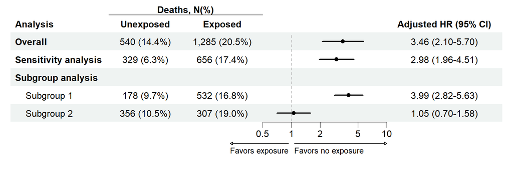

The plot will be made using the following data

| analysis | deaths_n_pct_0 | deaths_n_pct_1 | hr_ci | hr_est | hr_lcl | hr_ucl |
| --- | --- | --- | --- | --- | --- | --- |
| Overall | 540 (14.4%) | 1,285 (20.5%) | 3.46 (2.10-5.70) | 3.464894 | 2.1045728 | 5.704480 |
| Sensitivity analysis | 329 (6.3%) | 656 (17.4%) | 2.98 (1.96-4.51) | 2.976764 | 1.9631922 | 4.513629 |
| Subgroup analysis |  |  |  | NA | NA | NA |
| Subgroup 1 | 178 (9.7%) | 532 (16.8%) | 3.99 (2.82-5.63) | 3.985346 | 2.8220784 | 5.628115 |
| Subgroup 2 | 356 (10.5%) | 307 (19.0%) | 1.05 (0.70-1.58) | 1.054229 | 0.7037221 | 1.579316 |

Data from S:/Stat day May 2025/forest_plots/data/forest_plot_regression.rds

## 4.1 Making a basic forest plot

We can make a forest plot with `forestploter::forest()`. The layout of the forest plot is determined by the provided data.frame. Column names are used as a header, and the content of the data.frame will be shown in the forest plot. Furthermore, confidence intervals are drawn in specified column(s). This means that before we can make our forest plot, we need to manually add a column with empty values, where we will draw the confidence intervals. To make things a bit easier, we will also rearrange the columns of our data, so that the leftmost columns in the data match the layout of the forest plot we want to make, with the rightmost column containing the numerical estimates needed to draw the confidence intervals. Finally, we also rename the columns.

```r
# Load data
path_data <- "S:/Stat day May 2025/forest_plots/data/"
fp_dat <- readRDS(paste0(path_data, "forest_plot_regression.rds"))

# Add empty column and reorder columns.
fp_dat[[" "]] <- paste(rep(" ", 20), collapse = " ")
fp_dat <- fp_dat[, c(1:3, 8, 4:7)]

# Rename columns
names(fp_dat)[names(fp_dat) == "analysis"] <- "Analysis"
names(fp_dat)[names(fp_dat) == "deaths_n_pct_0"] <- "Unexposed"
names(fp_dat)[names(fp_dat) == "deaths_n_pct_1"] <- "Exposed"
names(fp_dat)[names(fp_dat) == "hr_ci"] <- "Adjusted HR (95% CI)"
```

The data now looks like this:

|  | Deaths, N(%) | Deaths, N(%) |  | Adjusted HR (95% CI) | hr_est | hr_lcl | hr_ucl |
| --- | --- | --- | --- | --- | --- | --- | --- |
| Overall | 540 (14.4%) | 1,285 (20.5%) | ⠀ ⠀ ⠀ ⠀ ⠀ | 3.46 (2.10-5.70) | 3.464894 | 2.1045728 | 5.704480 |
| Sensitivity analysis | 329 (6.3%) | 656 (17.4%) | ⠀ ⠀ ⠀ ⠀ ⠀ | 2.98 (1.96-4.51) | 2.976764 | 1.9631922 | 4.513629 |
| Subgroup analysis |  |  | ⠀ ⠀ ⠀ ⠀ ⠀ |  | NA | NA | NA |
| Subgroup 1 | 178 (9.7%) | 532 (16.8%) | ⠀ ⠀ ⠀ ⠀ ⠀ | 3.99 (2.82-5.63) | 3.985346 | 2.8220784 | 5.628115 |
| Subgroup 2 | 356 (10.5%) | 307 (19.0%) | ⠀ ⠀ ⠀ ⠀ ⠀ | 1.05 (0.70-1.58) | 1.054229 | 0.7037221 | 1.579316 |

We are now ready to produce a basic forest plot using the following code:

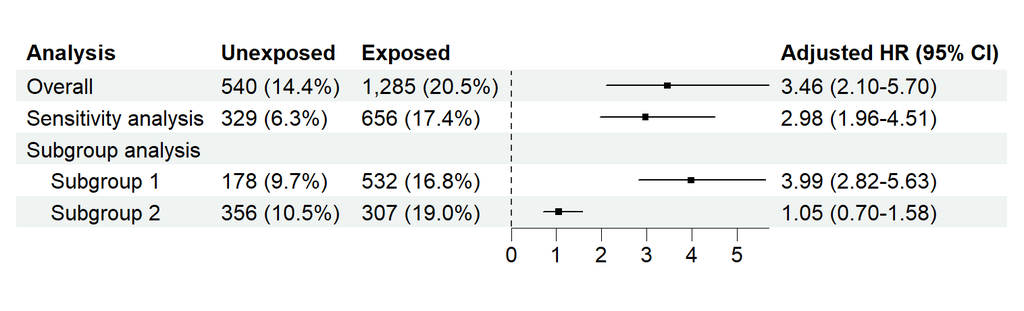

```r
fp_plot <- forest(
  data = fp_dat[, 1:5],
  est = fp_dat$hr_est,
  lower = fp_dat$hr_lcl,
  upper = fp_dat$hr_ucl,
  ci_column = 4
)

fp_plot
```

Notes:

- In the `data` argument we specify the data.frame that is used as a layout for the plot. Note that this includes the empty column we have made where the confidence intervals are to be displayed, but **not** the columns with the estimates used to draw confidence intervals.
- The `est`, `lower`, and `upper` arguments specify the vectors used to draw the confidence intervals.
- `ci_column`is used to specify the number of the column (in the data.frame given in the `data` argument) where the confidence intervals will be drawn.
- The width of the column where the confidence intervals are drawn is determined by the width of the column. Increase/decrease the number of spaces in the empty column to achieve the column width you want.

We can see that several nice features are added to the forest plot by default:

- x-axis under the confidence intervals.
- Striped rows.
- A vertical reference line indicating a null association (although in this case it is incorrectly set at zero, not at one).

**Exercise**

Try to make the same forest plot using the following data.frame, where we do not reorder the columns in `fp_dat` before using `forest()`. What changes has to be made to the `data` and `ci_column` argument to make it work correctly?

```r
# Load data
path_data <- "S:/Stat day May 2025/forest_plots/data/"
fp_dat <- readRDS(paste0(path_data, "forest_plot_regression.rds"))

# Add empty column
fp_dat[[" "]] <- paste(rep(" ", 20), collapse = " ")

# Rename columns
names(fp_dat)[names(fp_dat) == "analysis"] <- "Analysis"
names(fp_dat)[names(fp_dat) == "deaths_n_pct_0"] <- "Unexposed"
names(fp_dat)[names(fp_dat) == "deaths_n_pct_1"] <- "Exposed"
names(fp_dat)[names(fp_dat) == "hr_ci"] <- "Adjusted HR (95% CI)"
```

**Solution**

```r
forest(
  data = fp_dat[, c(1:3, 8, 4)],
  est = fp_dat$hr_est,
  lower = fp_dat$hr_lcl,
  upper = fp_dat$hr_ucl,
  ci_column = 4
)
```

If we do not reorder the columns, we can reorder the column on the fly in the `data` argument. Note that we **still** have to specify `ci_column = 4`, since the empty column is still the fourth column in `fp_dat[, c(1:3, 8, 4)]`.

So far, so good. Next, lets make some modifications to the x-axis using some additional arguments in `forest()`.

**Exercise**

- Log transform the x axis
- Change the x-axis limits
- Change the tick marks
- Add arrows under the x-axis.

**Hint 1**

Look at the documentation for `forest()`

```r
?forest
```

**Hint 2**

The arguments of interest in `forest()` are

- Log transform the x axis: `x_trans`
- Change the x-axis limits: `xlim`
- Change the tick marks: `ticks_at`
- Add arrows under the x-axis: `arrow_lab`

**Solution**

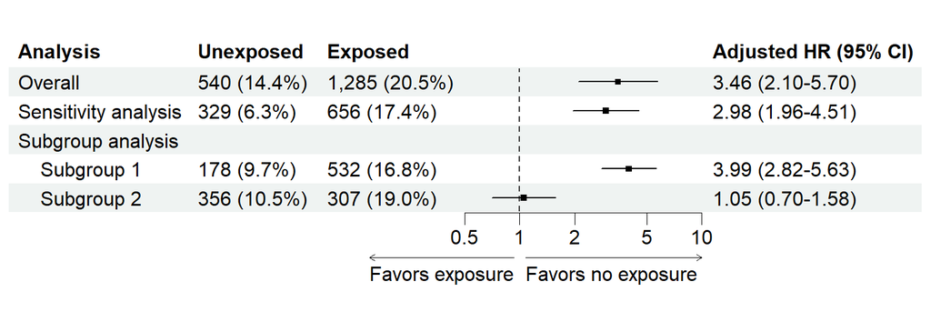

```r
fp_plot <- forest(
  data = fp_dat[, 1:5],
  est = fp_dat$hr_est,
  lower = fp_dat$hr_lcl,
  upper = fp_dat$hr_ucl,
  ci_column = 4,
  x_trans = "log",
  xlim = c(0.5, 10),
  ticks_at = c(0.5, 1, 2, 5, 10),
  arrow_lab = c("Favors exposure", "Favors no exposure")
)

fp_plot
```

Note that specifying `x_trans = "log"` automatically puts the reference line at one as desired.

## 4.2 Forest plot themes

The graphical parameters of the forest plot, e.g. colours, text alignmetn, and font-sizes, can be controlled with a theme. The default theme can be adjusted by creating a theme with `forest_theme()` and passing the object in the `theme` argument in `forest()`.

**Exercise**

Apply the following theme to the forest plot.

```r
fp_theme <- forest_theme(
  # Make the reference line a grey dashed line
  refline_gp = gpar(lty = "dashed", col = "grey"),
  # Change font-size of the arrows below the x-axis
  arrow_gp = gpar(fontsize = 10),
  # Change the appereance of the arrows below the x-axis.
  arrow_type = "closed",
  # Change shape of point estimate
  ci_pch = 16,
  # Change line width of CI
  ci_lwd = 2,
  # Change cell padding that is used in the body of the table
  core = list(
    padding = unit(c(10, 5), "mm")
  ),
  # Change cell padding in header
  colhead = list(padding = unit(c(10, 5), "mm"))
)
```

**Solution**

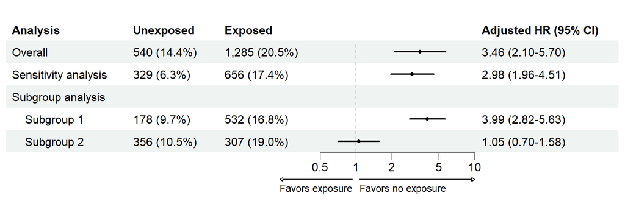

```r
fp_theme <- forest_theme(
  # Make the reference line a grey dashed line
  refline_gp = gpar(lty = "dashed", col = "grey"),
  # Change font-size of the arrows below the x-axis
  arrow_gp = gpar(fontsize = 10),
  # Change the appereance of the arrows below the x-axis.
  arrow_type = "closed",
  # Change shape of point estimate
  ci_pch = 16,
  # Change line width of CI
  ci_lwd = 2,
  # Change cell padding that is used in the body of the table
  core = list(
    padding = unit(c(10, 5), "mm")
  ),
  # Change cell padding in header
  colhead = list(padding = unit(c(10, 5), "mm"))
)

fp_plot <- forest(
  data = fp_dat[, 1:5],
  est = fp_dat$hr_est,
  lower = fp_dat$hr_lcl,
  upper = fp_dat$hr_ucl,
  ci_column = 4,
  x_trans = "log",
  xlim = c(0.5, 10),
  ticks_at = c(0.5, 1, 2, 5, 10),
  arrow_lab = c("Favors exposure", "Favors no exposure"),
  theme = fp_theme
)

fp_plot
```

## 4.3 Adding text

Text can be added to the forest plot using `add_text()`. We will use this function to add a line of text above the header row with the column names.

**Exercise**

Use `add_text()` to add the text “Deaths, N(%)” in a line above the header, spanning the columns “Unexposed” and “Exposed”. Make the text bold.

Note that the documentation for the `row` parameter seems to be wrong. You need to specify `row = 0` to get the header above the column labels.

**Hint 1**

Look at the documentation for `add_text()`

```r
?add_text()
```

**Hint 2**

The text can be made bold using `gp = gpar(fontface = "bold")`

**Solution**

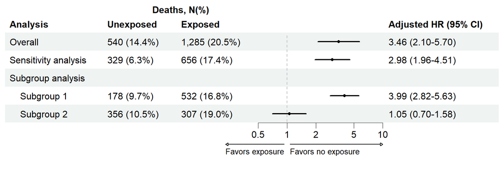

```r
fp_plot <- add_text(
  plot = fp_plot,
  text = "Deaths, N(%)",
  row = 0,
  col = 2:3,
  part = "header",
  gp = gpar(fontface = "bold")
)

fp_plot
```

## 4.4 Adding borders

Borders can be added to any cell in the forest plot using `add_border()`.

**Exercise**

Underline the “Deaths, N(%)” text spanning column two and tree.

**Hint 1**

Look at the documentation for `add_border()`.

```r
?add_text()
```

**Hint 2**

The width of the border can be made thinner using `gp = gpar(lwd = 0.5)`.

**Solution**

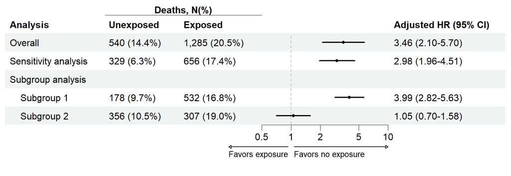

```r
fp_plot <- add_border(
  plot = fp_plot,
  row  = 0,
  col  = 2:3,
  part = "header",
  where = "bottom",
  gp = gpar(lwd = 0.5)
)

fp_plot
```

## 4.5 Further editing the plot

The final basic function from **forestploter** we will introduce in this example is `edit_plot()`. This function can be used to edit the graphical parameters of the text, background and CI’s in the forest plot.

**Exercise**

- Change the font face of the three rows of the first column to bold.
- Center-align text in column two, three, and five.
- Center-align text in header.

To specify center-alignment of text, add arguments `hjust = unit(0.5, "npc")` and `x = unit(0.5, "npc")` to `edit_plot()`.

**Solution**

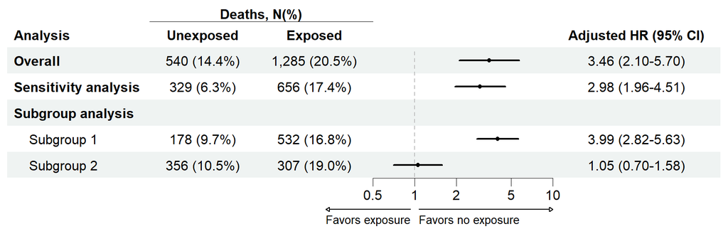

```r
# Make first three rows of column one bold
fp_plot <- edit_plot(
  plot = fp_plot,
  col = 1,
  row = 1:3,
  which = "text",
  gp = gpar(fontface = "bold")
)

# Center-align text in column two, three, and five
fp_plot <- edit_plot(
  plot = fp_plot,
  col = c(2, 3, 5),
  part = "body",
  which = "text",
  hjust = unit(0.5, "npc"),
  x = unit(0.5, "npc")
)

# Center-align text in the header columns
fp_plot <- edit_plot(
  plot = fp_plot,
  col = c(2, 3, 5),
  part = "header",
  which = "text",
  hjust = unit(0.5, "npc"),
  x = unit(0.5, "npc")
)

fp_plot
```

## 4.6 Final plot

The final plot should now look as below

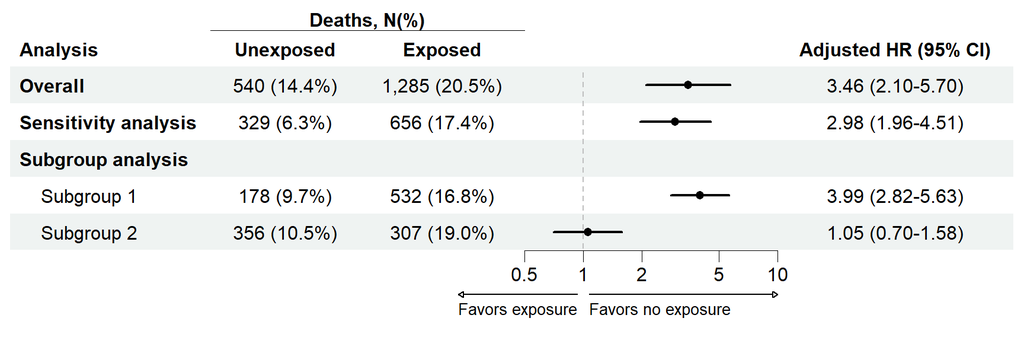

```r
# Load data
path_data <- "S:/Stat day May 2025/forest_plots/data/"
fp_dat <- readRDS(paste0(path_data, "forest_plot_regression.rds"))

# Add empty column and reorder columns
fp_dat[[" "]] <- paste(rep(" ", 20), collapse = " ")
fp_dat <- fp_dat[, c(1:3, 8, 4:7)]

# Rename columns
names(fp_dat)[names(fp_dat) == "analysis"] <- "Analysis"
names(fp_dat)[names(fp_dat) == "deaths_n_pct_0"] <- "Unexposed"
names(fp_dat)[names(fp_dat) == "deaths_n_pct_1"] <- "Exposed"
names(fp_dat)[names(fp_dat) == "hr_ci"] <- "Adjusted HR (95% CI)"

# Specify theme
fp_theme <- forest_theme(
  refline_gp = gpar(lty = "dashed", col = "grey"),
  arrow_gp = gpar(fontsize = 10),
  arrow_type = "closed",
  ci_pch = 16,
  ci_lwd = 2,
  core = list(
    padding = unit(c(10, 5), "mm")
  ),
  colhead = list(padding = unit(c(10, 5), "mm"))
)

# Make forest plot
fp_plot <- forest(
  data = fp_dat[, 1:5],
  est = fp_dat$hr_est,
  lower = fp_dat$hr_lcl,
  upper = fp_dat$hr_ucl,
  ci_column = 4,
  x_trans = "log",
  sizes = 0.6,
  xlim = c(0.5, 10),
  ticks_at = c(0.5, 1, 2, 5, 10),
  arrow_lab = c("Favors exposure", "Favors no exposure"),
  theme = fp_theme
)

# Add text in header
fp_plot <- add_text(
  plot = fp_plot,
  text = "Deaths, N(%)",
  row = 0,
  col = 2:3,
  part = "header",
  gp = gpar(fontface = "bold")
)

# Add line under header text
fp_plot <- add_border(
  plot = fp_plot,
  row  = 0,
  col  = 2:3,
  part = "header",
  where = "bottom",
  gp = gpar(lwd = 0.5)
)

# Make first three rows of column one bold
fp_plot <- edit_plot(
  plot = fp_plot,
  col = 1,
  row = 1:3,
  which = "text",
  gp = gpar(fontface = "bold")
)

# Center-align text in column two, three, and five
fp_plot <- edit_plot(
  plot = fp_plot,
  col = c(2, 3, 5),
  part = "body",
  which = "text",
  hjust = unit(0.5, "npc"),
  x = unit(0.5, "npc")
)

# Center-align text in the header columns
fp_plot <- edit_plot(
  col = c(2, 3, 5),
  plot = fp_plot,
  part = "header",
  which = "text",
  hjust = unit(0.5, "npc"),
  x = unit(0.5, "npc")
)

fp_plot
```

## 4.7 Saving the forest plot

Finally, we probably want to save our finished forest plot. Below is an example of how to save the the plot using base R functions.

```r
# Get width and height of forest plot
fp_plot_wh <- get_wh(plot = fp_plot, unit = "in")
png(
  'forest_plot.png',
  res = 300,
  width = fp_plot_wh[1],
  height = fp_plot_wh[2],
  units = "in"
)
fp_plot
invisible(dev.off())
```

Since **forestploter** is both built on grid graphics, we can also use `ggplot2::ggsave()` to save the forest plot, which might feel more familiar to some people.

`ggplot2::ggsave()` can save any grid object, not just plots produced by **ggplot2**.

```r
# Get width and height of forest plot
fp_plot_wh <- get_wh(fp_plot, unit = "in")
ggplot2::ggsave(
  filename = "forest_plot.svg",
  plot = fp_plot,
  width = fp_plot_wh[1],
  height = fp_plot_wh[2],
  units = "in"
)
```

# 5 Forest plot - multiple CI columns

Multiple CI columns can be drawn in a plot by specifying a vector of column positions in `ci_column`, and by specifying lists of vectors of the same length as the vector given in `ci_column` in arguments used to draw the CI’s, e.g. `est`, `lower`, and `upper`. The vectors in the first elements of the lists in `est`, `lower`, and `upper` will be used to draw the CI’s in the column indicated in the first element of `ci_column` and so forth. Note that this also applies to arguments controlling graphical parameters of the CI columns, e.g. x-axes. This means that we can control the look of each CI column separately.

In this section we will show how to make a simple forest plot with two CI columns, as seen below.

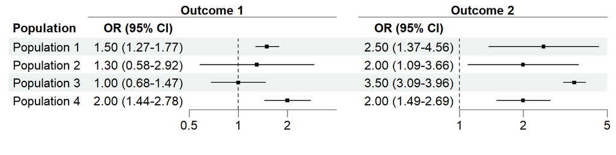

The plot is made using the following data.

| population | or_ci_1 | or_ci_2 | or_est_1 | or_lcl_1 | or_ucl_1 | or_est_2 | or_lcl_2 | or_ucl_2 |
| --- | --- | --- | --- | --- | --- | --- | --- | --- |
| Population 1 | 1.50 (1.27-1.77) | 2.50 (1.37-4.56) | 1.5 | 1.27 | 1.77 | 2.5 | 1.37 | 4.56 |
| Population 2 | 1.30 (0.58-2.92) | 2.00 (1.09-3.66) | 1.3 | 0.58 | 2.92 | 2.0 | 1.09 | 3.66 |
| Population 3 | 1.00 (0.68-1.47) | 3.50 (3.09-3.96) | 1.0 | 0.68 | 1.47 | 3.5 | 3.09 | 3.96 |
| Population 4 | 2.00 (1.44-2.78) | 2.00 (1.49-2.69) | 2.0 | 1.44 | 2.78 | 2.0 | 1.49 | 2.69 |

Data from S:/Stat day May 2025/forest_plots/data/forest_plot_multiple_ci.rds

**Exercise**

Make the above plot using the provided data. The documentation in `forest()` on how to produce multiple CI columns is lacking unfortunately, but there is some documentation and examples in the introduction vignette, see section “Multiple CI columns”.

```r
vignette("forestploter-intro", package = "forestploter")
```

Note that an additional empty column is used to separate the “Outcome 1” and “Outcome 2” columns. Thus, the plot has three columns with an empty header / column name. One way to have multiple columns with an empty column name in the same data.frame, is to use a different number of spaces in each column name.

```r
fp_dat$` ` <- paste0(rep(" ", 10), collapse = " ")
fp_dat$`  ` <- paste0(rep(" ", 10), collapse = " ")
fp_dat$`   ` <- paste0(rep(" ", 10), collapse = " ")
```

**Solution**

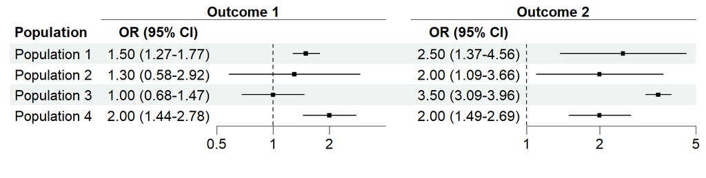

```r
# Load data
path_data <- "S:/Stat day May 2025/forest_plots/data/"
fp_dat <- readRDS(paste0(path_data, "forest_plot_multiple_ci.rds"))

# Make multiple empty columns. Two for drawing CI's, and one to separate
# the two parts of the plot
fp_dat$` ` <- paste0(rep(" ", 20), collapse = " ")
fp_dat$`  ` <- paste0(rep(" ", 2), collapse = " ")
fp_dat$`   ` <- paste0(rep(" ", 20), collapse = " ")
names(fp_dat)[names(fp_dat) == "or_ci_1"] <- "OR (95% CI)"
names(fp_dat)[names(fp_dat) == "or_ci_2"] <- "OR (95% CI)"
names(fp_dat)[names(fp_dat) == "population"] <- "Population"

fp_plot <- forest(
  data = fp_dat[, c(1, 2, 10, 11, 3, 12)],
  est = list(fp_dat$or_est_1, fp_dat$or_est_2),
  lower = list(fp_dat$or_lcl_1, fp_dat$or_lcl_2),
  upper = list(fp_dat$or_ucl_1, fp_dat$or_ucl_2),
  ci_column = c(3, 6),
  x_trans = "log",
  xlim = list(c(0.5, 4), c(1, 5)),
  ticks_at = list(c(0.5, 1, 2, 5), c(1, 2, 5))
)

# Add header text
fp_plot <- add_text(
  plot = fp_plot,
  text = "Outcome 1",
  row = 0,
  col = 2:3,
  part = "header",
  gp = gpar(fontface = "bold")
)

fp_plot <- add_text(
  plot = fp_plot,
  text = "Outcome 2",
  row = 0,
  col = 5:6,
  part = "header",
  gp = gpar(fontface = "bold")
)

# Add borders
fp_plot <- add_border(
  plot = fp_plot,
  row = 0,
  col = 2:3,
  part = "header",
  where = "bottom",
  gp = gpar(lwd = 0.5)
)

fp_plot <- add_border(
  plot = fp_plot,
  row = 0,
  col = 5:6,
  part = "header",
  where = "bottom",
  gp = gpar(lwd = 0.5)
)

# Center-align columns and headers
fp_plot <- edit_plot(
  plot = fp_plot,
  col = c(2, 5),
  part = "body",
  which = "text",
  hjust = unit(0.5, "npc"),
  x = unit(0.5, "npc")
)

fp_plot <- edit_plot(
  plot = fp_plot,
  col = c(2, 5),
  part = "header",
  which = "text",
  hjust = unit(0.5, "npc"),
  x = unit(0.5, "npc")
)

fp_plot
```

# 6 Forest plot - Grouped CI column

This section assumes the reader has read Section 5.

To make a forest plot with a grouped CI column we can specify a single column in `ci_column`, and lists of columns in `est`, `lower`, `upper`. Using the same data as in Section 5, we can make the plot below.

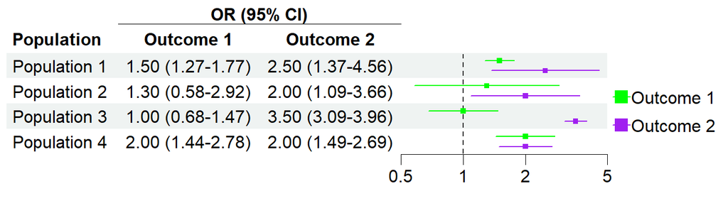

**Exercise**

Make the above plot using the provided data. The documentation in `forest()` on how to produce grouped CI columns is lacking unfortunately, but there is some documentation and examples in the introduction vignette, see section “Multiple CI columns”.

```r
vignette("forestploter-intro", package = "forestploter")
```

**Hint 1**

to control the spacing between CI’s, use `nudge_y` in `forest()`.

Graphical parameters of the CI’s and the legend can be controlled with `forest_theme()`.

**Solution**

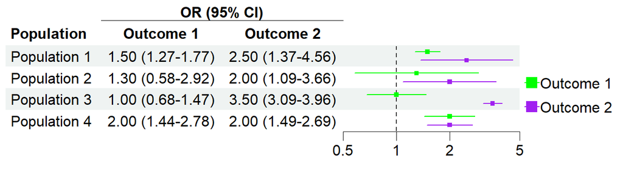

```r
# Load data
path_data <- "S:/Stat day May 2025/forest_plots/data/"
fp_dat <- readRDS(paste0(path_data, "forest_plot_multiple_ci.rds"))

# Make an empty column and rename columns
fp_dat$` ` <- paste0(rep(" ", 20), collapse = " ")
names(fp_dat)[names(fp_dat) == "or_ci_1"] <- "Outcome 1"
names(fp_dat)[names(fp_dat) == "or_ci_2"] <- "Outcome 2"
names(fp_dat)[names(fp_dat) == "population"] <- "Population"

fp_theme <- forest_theme(
  ci_col = c("green", "purple"),
  legend_name = "",
  legend_value = c("Outcome 1", "Outcome 2")
)

fp_plot <- forest(
  data = fp_dat[, c(1, 2, 3, 10)],
  est = list(fp_dat$or_est_1, fp_dat$or_est_2),
  lower = list(fp_dat$or_lcl_1, fp_dat$or_lcl_2),
  upper = list(fp_dat$or_ucl_1, fp_dat$or_ucl_2),
  ci_column = 4,
  x_trans = "log",
  xlim = c(0.5, 5),
  ticks_at = c(0.5, 1, 2, 5),
  nudge_y = 0.4,
  theme = fp_theme
)

# Add header text
fp_plot <- add_text(
  plot = fp_plot,
  text = "OR (95% CI)",
  row = 0,
  col = 2:3,
  part = "header",
  gp = gpar(fontface = "bold")
)

# Add borders
fp_plot <- add_border(
  plot = fp_plot,
  row = 0,
  col = 2:3,
  part = "header",
  where = "bottom",
  gp = gpar(lwd = 0.5)
)

# Center-align columns and headers
fp_plot <- edit_plot(
  plot = fp_plot,
  col = c(2, 3),
  part = "body",
  which = "text",
  hjust = unit(0.5, "npc"),
  x = unit(0.5, "npc")
)

fp_plot <- edit_plot(
  plot = fp_plot,
  col = c(2, 3),
  part = "header",
  which = "text",
  hjust = unit(0.5, "npc"),
  x = unit(0.5, "npc")
)

fp_plot
```

# 7 Forest plot - Meta-analysis

This section assumes the reader is familiar with meta-analysis.

Packages like **meta** and **metafor** that can facilitate meta-analysis, also comes with functions that makes forest plots of the results. Making publication-ready forest plots using these packages is easy, so if you need to make a forest plot from a meta-analysis, it is worthwhile to explore those packages. That being said, it is often necessary to make adjustments to the plots these packages can make. Some types of adjustments are easy to do. Others, not so much. The goal of this section is to illustrate how one can make forest plots using **forestploter** that incorporates some of the features other meta-analysis packages have. If you need to make a forest plot from a meta-analysis, and if it is difficult to achieve the desired result using other packages, maybe using **forestploter** is a viable alternative.

The forest plot we will make is shown below.

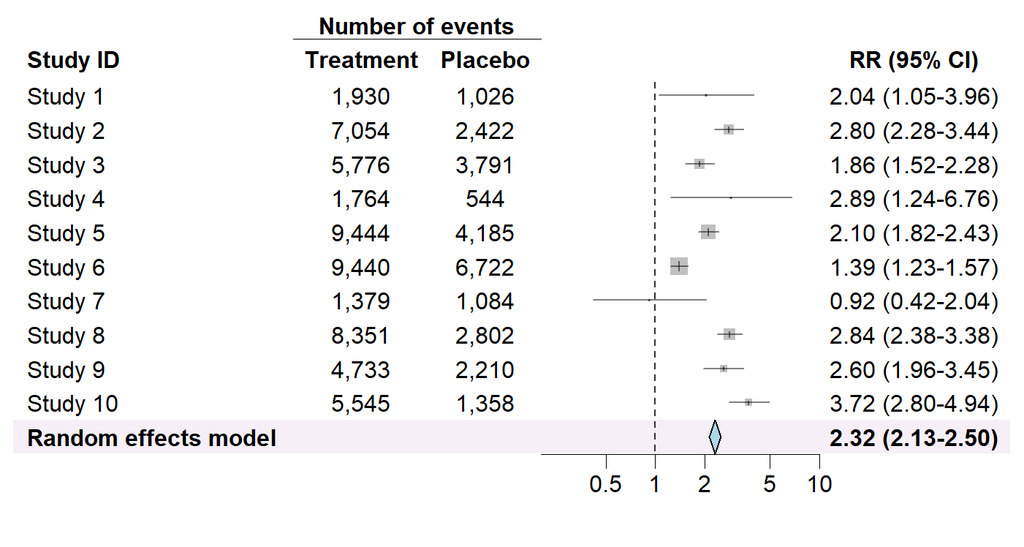

We will use the following data to make the plot:

| study | n_events_treatment | n_events_placebo | rr_ci | rr_estimate | rr_se | rr_lcl | rr_ucl | weight |
| --- | --- | --- | --- | --- | --- | --- | --- | --- |
| Study 1 | 1,930 | 1,026 | 2.04 (1.05-3.96) | 2.0429904 | 0.33829499 | 1.0526980 | 3.964869 | 0.1828982 |
| Study 2 | 7,054 | 2,422 | 2.80 (2.28-3.44) | 2.8000186 | 0.10552976 | 2.2768382 | 3.443417 | 0.5863136 |
| Study 3 | 5,776 | 3,791 | 1.86 (1.52-2.28) | 1.8604977 | 0.10452597 | 1.5158451 | 2.283513 | 0.5919441 |
| Study 4 | 1,764 | 544 | 2.89 (1.24-6.76) | 2.8931485 | 0.43327556 | 1.2375396 | 6.763669 | 0.1428041 |
| Study 5 | 9,444 | 4,185 | 2.10 (1.82-2.43) | 2.1039031 | 0.07337295 | 1.8220883 | 2.429305 | 0.8432743 |
| Study 6 | 9,440 | 6,722 | 1.39 (1.23-1.57) | 1.3931172 | 0.06187353 | 1.2340133 | 1.572735 | 1.0000000 |
| Study 7 | 1,379 | 1,084 | 0.92 (0.42-2.04) | 0.9213871 | 0.40600893 | 0.4157577 | 2.041944 | 0.1523945 |
| Study 8 | 8,351 | 2,802 | 2.84 (2.38-3.38) | 2.8374338 | 0.08966197 | 2.3801478 | 3.382576 | 0.6900755 |
| Study 9 | 4,733 | 2,210 | 2.60 (1.96-3.45) | 2.6042730 | 0.14402996 | 1.9637479 | 3.453721 | 0.4295879 |
| Study 10 | 5,545 | 1,358 | 3.72 (2.80-4.94) | 3.7155826 | 0.14486455 | 2.7971498 | 4.935579 | 0.4271130 |
| Random effects model |  |  | 2.32 (2.13-2.50) | 2.3172352 | 0.09507191 | 2.1308942 | 2.503576 | 1.0000000 |

Data from S:/Stat day May 2025/forest_plots/data/forest_plot_meta_analysis.rds

**Exercise**

Make the above plot. The main aspects of the plot that have been modified are:

- The size of point estimates depends on the weight the study was given.
- The shape of the point estimate in the last row is a diamond.
- Background colours have been modified, so that only the last row has a non-white background colour.

**Hint 1**

- The size of point estimates can be controlled using the `sizes` argument in `forest()`.
- Use the `is_summary` argument in `forest()` to make the last row a summary line, and control the graphical parameters of summary lines using `forest_theme()`.
- Remove the background colour using `forest_theme()`, then use `edit_plot()` to add background colour to the last row.

**Solution**

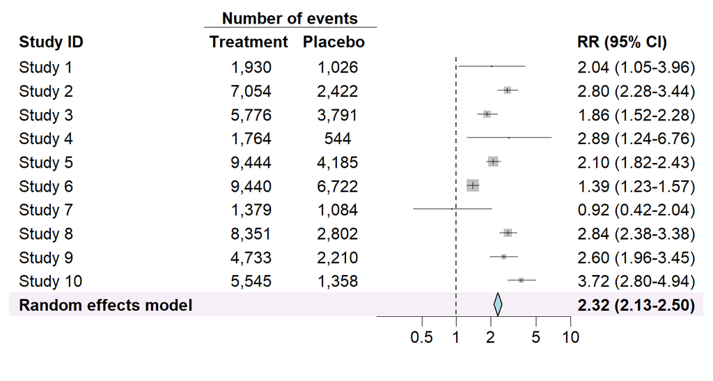

```r
path_data <- "S:/Stat day May 2025/forest_plots/data/"
fp_dat <- readRDS(paste0(path_data, "forest_plot_meta_analysis.rds"))

fp_dat$` ` <- paste0(rep(" ", 20), collapse = " ")
names(fp_dat)[names(fp_dat) == "study"] <- "Study ID"
names(fp_dat)[names(fp_dat) == "n_events_treatment"] <- "Treatment"
names(fp_dat)[names(fp_dat) == "n_events_placebo"] <- "Placebo"
names(fp_dat)[names(fp_dat) == "rr_ci"] <- "RR (95% CI)"

fp_theme <- forest_theme(
  ci_alpha = 0.5,
  core = list(bg_params = list(fill = c("white"))),
  summary_col = "black",
  summary_fill = "lightblue"
)

fp_plot <-forest(
  data = fp_dat[, c(1:3, 10, 4)],
  est = fp_dat$rr_estimate,
  lower = fp_dat$rr_lcl,
  upper = fp_dat$rr_ucl,
  ci_column = 4,
  sizes = fp_dat$weight,
  x_trans = "log",
  xlim = c(0.2, 10),
  ticks_at = c(0.5, 1, 2, 5, 10),
  is_summary = 1:nrow(fp_dat) == nrow(fp_dat),
  theme = fp_theme
)

fp_plot <- add_text(
  plot = fp_plot,
  row = 0,
  text = "Number of events",
  part = "header",
  col = 2:3,
  gp = gpar(fontface = "bold")
)

# Add underline at the bottom of the header
fp_plot <- add_border(
  plot = fp_plot,
  part = "header",
  row = 0,
  col = 2:3,
  gp = gpar(lwd = 0.5)
)

fp_plot <- edit_plot(
  plot = fp_plot,
  row = 11,
  part = "body",
  which = "background",
  gp = gpar(fill = "#f6eff7")
)

fp_plot <- edit_plot(
  plot = fp_plot,
  row = 11,
  part = "body",
  which = "text",
  gp = gpar(fontface = "bold")
)

# Center-align text in columns
fp_plot <- edit_plot(
  fp_plot,
  col = c(2, 3, 5),
  part = "body",
  which = "text",
  hjust = unit(0.5, "npc"),
  x = unit(0.5, "npc")
)

# Center-align text in the header
fp_plot <- edit_plot(
  fp_plot,
  row = c(2, 3, 5),
  part = "header",
  which = "text",
  hjust = unit(0.5, "npc"),
  x = unit(0.5, "npc")
)

fp_plot
```